# PSTAT231HW6

### Exercise 9

Finally, set up a boosted tree model and workflow. Use the `xgboost` engine. Tune `trees`. Create a regular grid with 10 levels; let `trees` range from 10 to 2000. Specify `roc_auc` and again print an `autoplot()` of the results.

What do you observe?

What is the `roc_auc` of your best-performing boosted tree model on the folds? *Hint: Use `collect_metrics()` and `arrange()`.*

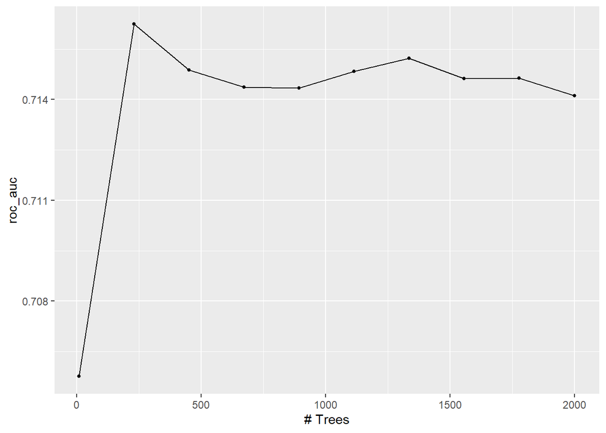

```r
set.seed(2000)
boost_spec <- boost_tree() %>%
  set_engine("xgboost") %>%
  set_mode("classification")

boost_wkflow <- workflow() %>%
  add_model(boost_spec %>%
  set_args(trees = tune())) %>%
  add_recipe(Pokemon_recipe)
boost_grid <- grid_regular(trees(range = c(10,2000)), levels = 10)

boost_tune_res <- tune_grid(
  boost_wkflow,
  resamples = Pokemon_folds,
  grid = boost_grid,
  metrics = metric_set(roc_auc)
)
autoplot(boost_tune_res)
```

```r
collect_metrics(boost_tune_res)%>%
  arrange(desc(mean))
```

```
## # A tibble: 10 x 7
##    trees .metric .estimator  mean     n std_err .config
##    <int> <chr>   <chr>      <dbl> <int>   <dbl> <chr>
##  1   231 roc_auc hand_till  0.716     5  0.0215 Preprocessor1_Model02
##  2  1336 roc_auc hand_till  0.715     5  0.0202 Preprocessor1_Model07
##  3   452 roc_auc hand_till  0.715     5  0.0211 Preprocessor1_Model03
##  4  1115 roc_auc hand_till  0.715     5  0.0201 Preprocessor1_Model06
##  5  1778 roc_auc hand_till  0.715     5  0.0195 Preprocessor1_Model09
##  6  1557 roc_auc hand_till  0.715     5  0.0198 Preprocessor1_Model08
##  7   673 roc_auc hand_till  0.714     5  0.0210 Preprocessor1_Model04
##  8   894 roc_auc hand_till  0.714     5  0.0202 Preprocessor1_Model05
##  9  2000 roc_auc hand_till  0.714     5  0.0190 Preprocessor1_Model10
## 10    10 roc_auc hand_till  0.706     5  0.0180 Preprocessor1_Model01
```

```r
#From the results we could observe that the model roc_auc reaches its maximum at around 231 trees.The maximum ROC_AUC is 0.7162454
```